# Cetaceans in the US

Anna Reynolds

2019-01-28

## Overview

The data for week 38 2018 #TidyTuesday contains data on the capture of cetaceans in the US described in an article by [The Pudding](https://pudding.cool/2017/07/cetaceans/) published in July 2017.

## Load data

```r
library(tidyverse)
library(summarytools)
library(here)
library(janitor)
library(knitr)
library(ggthemr)
library(ggridges)
library(ggalluvial)
library(paletteer)
library(scico)
#Import data
cetaceans <- read_csv(here("cetacean_us.csv")) %>% clean_names()
kable(head(cetaceans[,1:7]))
```

| x1 | species | id | name | sex | accuracy | birth_year |
| --- | --- | --- | --- | --- | --- | --- |
| 1 | Bottlenose | NOA0004614, AZA 428, MLF-428 | Dazzle | F | a | 1989 |
| 2 | Bottlenose | NOA0004386, AZA 138, IDR-73-1 | Tursi | F | a | 1973 |
| 3 | Bottlenose | NOA0002137, SWC-TTG-7816 | Starbuck | M | a | 1978 |
| 4 | Bottlenose | NOA0002690, SWF-TT-7903 | Sandy | F | a | 1979 |
| 5 | Bottlenose | NOA0004418, AZA 242, SWF-TT-7904, MH-82-36-TT (New England Aquarium) | Sandy | M | a | 1979 |
| 6 | Bottlenose | NOA0002725, SWC-TT-8014 | Nacha | F | a | 1980 |

```r
#Set theme
ggthemr(palette = "sky", set_theme = TRUE)
#View a summary of the data frame
view(dfSummary(cetaceans))

# set colors
sc_pal <- scico::scico(10, palette = "tokyo")[c(1, 4, 6)]
sc_pal2 <- scico::scico(10, palette = "devon")[c(1, 4, 6, 8)]
```

## Analysis/visualization

### What is the distribution over time of animals rescued, captured or born?

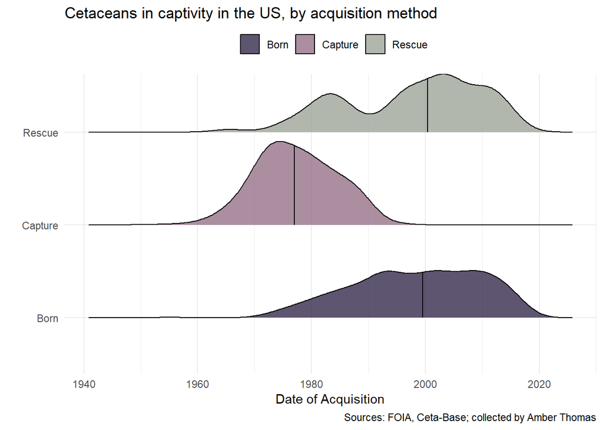

```r
#Filter data to those either born, captured or rescued
cetaceans2 <- cetaceans %>% filter(acquisition == "Capture" | acquisition == "Born" | acquisition == "Rescue")
#Density plot
ggplot(cetaceans2, aes(x = origin_date, y = acquisition, fill = acquisition)) + geom_density_ridges(scale = 0.9, alpha = 0.7, quantile_lines = TRUE, quantiles = 2) + guides(colour = FALSE) +
  theme_minimal() +
  labs(x = "Date of Acquisition",
       y = "",
       title = "Cetaceans in captivity in the US, by acquisition method",
       caption = "Sources: FOIA, Ceta-Base; collected by Amber Thomas") +
  scale_fill_manual(
    values = sc_pal,
    guide = guide_legend(title.vjust = .2,
                         label.position = "top",
                         keyheight = unit(4, units = "mm"),
                         keywidth=unit(14, units = "mm"),
                         nrow = 1,
                         reverse = TRUE)) +
  theme(legend.position = "top") +
  guides ( fill = guide_legend ( title = NULL ))
```

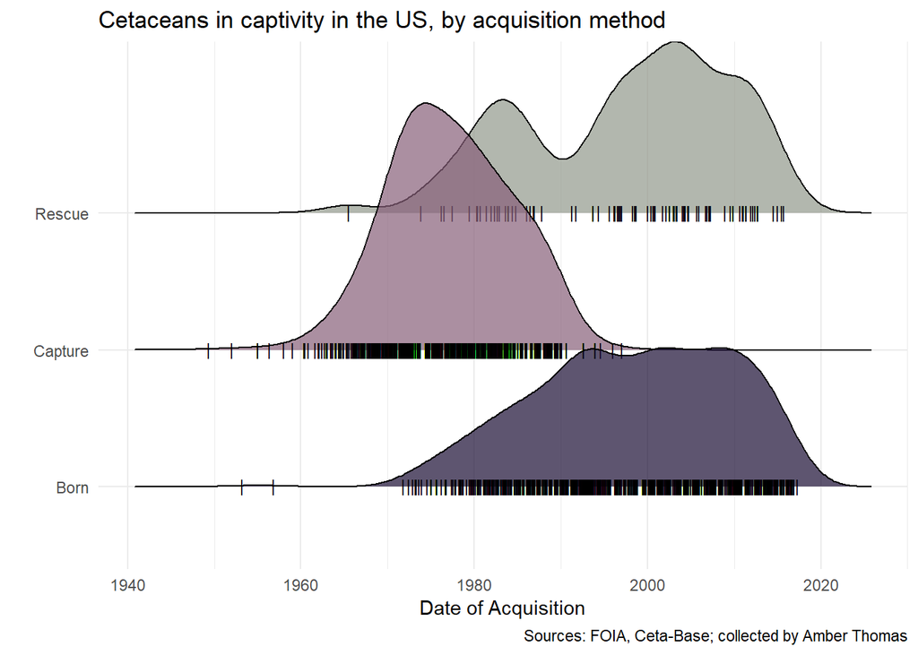

```r
ggplot(cetaceans2, aes(x = origin_date, y = acquisition, fill = acquisition)) +
  geom_density_ridges(
    jittered_points = TRUE,
    position = position_points_jitter(width = 0.05, height = 0),
    point_shape = '|', point_size = 3, point_alpha = 1, alpha = 0.7
  ) +
  theme_minimal() +
  labs(x = "Date of Acquisition",
       y = "",
       title = "Cetaceans in captivity in the US, by acquisition method",
       caption = "Sources: FOIA, Ceta-Base; collected by Amber Thomas") +
  theme ( legend.position = "none" ) +
  scale_fill_manual(
    values = sc_pal)
```

### What was the outcome for animals rescued or captured?

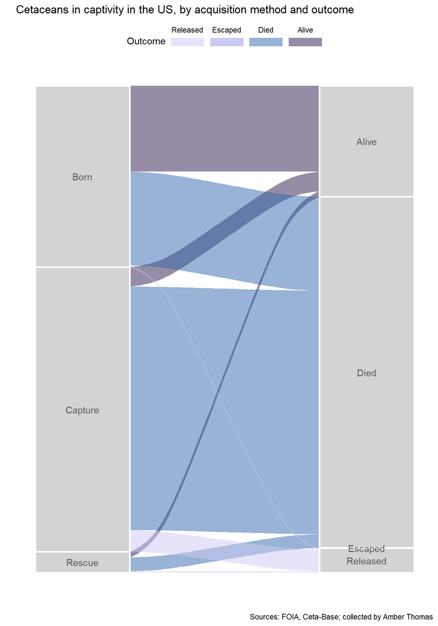

```r
library(colorblindr)
summary <- cetaceans2 %>% filter(status %in% c("Alive", "Died", "Escaped", "Released")) %>%  mutate(status = fct_lump(status, n = 9)) %>% group_by(acquisition, status) %>% summarise(n = n())

sankey <-
  ggplot(summary, aes(y = n, axis1 = acquisition, axis2 = status)) + geom_alluvium(aes(fill = status)) + geom_stratum(fill = "lightgrey", color = "white", size = 1) + geom_text(stat = "stratum", label.strata =
  T) + theme_minimal() + labs(
  x = " ",
  y = " ",
  title = "Cetaceans in captivity in the US, by acquisition method and outcome",
  caption = "Sources: FOIA, Ceta-Base; collected by Amber Thomas",
  fill = "Outcome"
  ) + theme (panel.grid.major = element_blank (),
  panel.grid.minor = element_blank ()) +
  scale_fill_manual(
    values = sc_pal2,
    guide = guide_legend(title.vjust = .2,
                         label.position = "top",
                         keyheight = unit(4, units = "mm"),
                         keywidth=unit(14, units = "mm"),
                         nrow = 1,
                         reverse = TRUE)) +
  theme(legend.position = "top") + scale_y_continuous ( breaks = NULL ) + scale_x_continuous ( breaks = NULL )

sankey
```

```r
library(rphylopic)
```

```r
dolphin <- name_search(text = "Bottlenose dolphin", options = "namebankID")[[1]]
orca <- name_search(text = "Orca", options = "namebankID")[[1]]
dolphin_image <- image_data("6682f694-1c10-4386-a6e5-361581400f15", size = 128)[[1]]
```

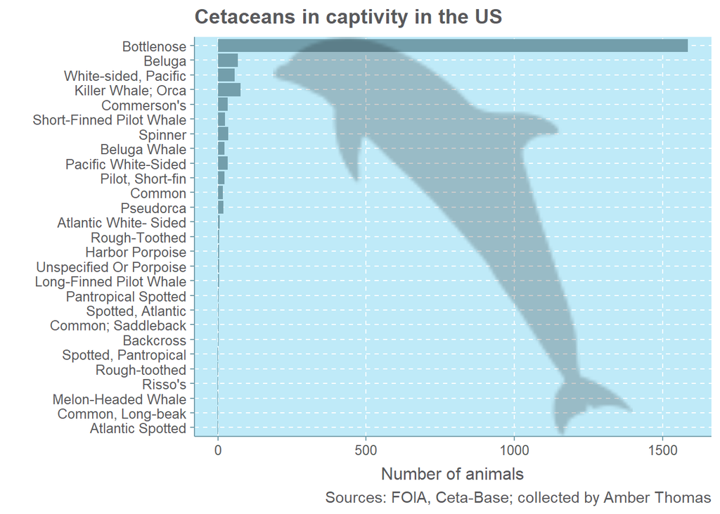

```r
#Top 10 species by acquisition method
species_10  <- cetaceans2 %>% group_by(acquisition, species) %>% summarise(species_n = n()) %>% top_n(species_n,n=10)
bar <- ggplot(species_10, aes(reorder(species, species_n), y = species_n)) + geom_bar(stat = "identity") + coord_flip() +
  add_phylopic(dolphin_image) +
  labs(x = "",
       y = "Number of animals",
       title = "Cetaceans in captivity in the US",
       caption = "Sources: FOIA, Ceta-Base; collected by Amber Thomas")
bar
```

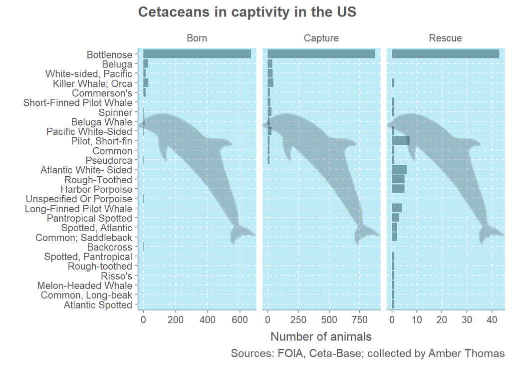

```r
bar + facet_wrap ( ~ acquisition, scales = "free_x")
```

## Package citations

Ciaran Tobin (NA). ggthemr: Themes for ggplot2. R package version 1.1.0.

Hadley Wickham (2017). tidyverse: Easily Install and Load the ‘Tidyverse’. R package version 1.2.1. https://CRAN.R-project.org/package=tidyverse

Hadley Wickham (2018). stringr: Simple, Consistent Wrappers for Common String Operations. R package version 1.3.0. https://CRAN.R-project.org/package=stringr

Yihui Xie (2018). knitr: A General-Purpose Package for Dynamic Report Generation in R. R package version 1.20.

Scott Chamberlain (2018). rphylopic: Get ‘Silhouettes’ of ‘Organisms’ from ‘Phylopic’. R package version 0.2.0. https://CRAN.R-project.org/package=rphylopic

Dominic Comtois (2018). summarytools: Tools to Quickly and Neatly Summarize Data. R package version 0.8.8. https://CRAN.R-project.org/package=summarytools

Sam Firke (2018). janitor: Simple Tools for Examining and Cleaning Dirty Data. R package version 1.1.1. https://CRAN.R-project.org/package=janitor

Claus O. Wilke (2018). ggridges: Ridgeline Plots in ‘ggplot2’. R package version 0.5.0. https://CRAN.R-project.org/package=ggridges

Jason Cory Brunson (2018). ggalluvial: Alluvial Diagrams in ‘ggplot2’. R package version 0.9.0. https://CRAN.R-project.org/package=ggalluvial